# Test a Perceptual Phenomenon

### Analyzing the Stroop Effect

Perform the analysis in the space below. Remember to follow [the instructions](https://docs.google.com/document/d/1-OkpZLjG_kX9J6LIQ5IltsqMzVWjh36QpnP2RYpVdPU/pub?embedded=True) and review the [project rubric](https://review.udacity.com/#!/rubrics/71/view) before submitting. Once you've completed the analysis and write up, download this file as a PDF or HTML file and submit in the next section.

(1) What is the independent variable? What is the dependent variable?

Indepent Variable: Task Condition (Congruent or Incongruent)

Dependent Variable: Time taken to complete the task

(2) What is an appropriate set of hypotheses for this task? What kind of statistical test do you expect to perform? Justify your choices.

Null Hypothesis: Mean Population Time Taken To Complete a Congruent Task (u1) = Mean Population Time Taken To Complete an Incongruent Task(u2)

Alternative Hypothesis: u1 != u2

To test the set of hypothesis, I expect to perform a paired t-test as we want to compare each of the participants times individually rather than collectively, as we want to know whether the time taken by each participant to complete both types of tasks are equal or not.

In addition to this, we have a small sample size (less than 30), and because of this we cannot assume that the sample distribution is normal.

To use a z-test, we need a large amount of samples (like 10000), to normalize the distribution. This leaves us with the t-test as the best way to find the differences in population mean.

(3) Report some descriptive statistics regarding this dataset. Include at least one measure of central tendency and at least one measure of variability. The name of the data file is 'stroopdata.csv'.

```python
# Perform the analysis here
import pandas as pd
import numpy as np
import scipy.stats as stats
import matplotlib.pyplot as plt
% matplotlib inline
df = pd.read_csv("stroopdata.csv")

print(df['Congruent'].count())
print('\n')
print(df.mean())
print('\n')
print(df.median())
print('\n')
print(df.std())
print('\n')
print(df.round(0).mode())
df.head()
```

```
24


Congruent      14.051125
Incongruent    22.015917
dtype: float64


Congruent      14.3565
Incongruent    21.0175
dtype: float64


Congruent      3.559358
Incongruent    4.797057
dtype: float64


   Congruent  Incongruent
0       12.0         21.0
1       15.0          NaN
```

|  | Congruent | Incongruent |
| --- | --- | --- |
| 0 | 12.079 | 19.278 |
| 1 | 16.791 | 18.741 |
| 2 | 9.564 | 21.214 |
| 3 | 8.630 | 15.687 |
| 4 | 14.669 | 22.803 |

The information on a total of 24 of each type of task is in the dataset.

The mean time taken to complete a congruent task was around 14 seconds, while the mean time taken to complete a incongruent task was around 22 seconds.

The median times for both tasks were close to the mean, at around 14.36 and 21.02 respectively.

People most commonly took between 12 and 13 seconds or between 15 and 16 seconds, to complete congruent tasks, while people most commonly took between 21 and 22 seconds to complete incongruent tasks. In other words, the mode of the time taken to complete congruent tasks, rounded to the nearest second, was 12 seconds and 15 seconds, while the mode of the incronguent tasks rounded the same way was 21 seconds.

The standard deviation of the congruent tasks was around 3.56 seconds, while the standard deviation of the incongruent tasks was about 4.80 seconds.

The shortest time it took someone to complete a congruent task was 8.63 seconds, while the shortest time taken to complete an incongruent task was around 15.69 seconds.

The longest time it took to complete a congruent task was around 22.33 seconds while the longest time taken to complete an incongruent task was around 35.26 seconds.

(4) Provide one or two visualizations that show the distribution of the sample data. Write one or two sentences noting what you observe about the plot or plots.

```
array([[<matplotlib.axes._subplots.AxesSubplot object at 0x7fa905ccfef0>,
        <matplotlib.axes._subplots.AxesSubplot object at 0x7fa8dccbd390>]], dtype=object)
```

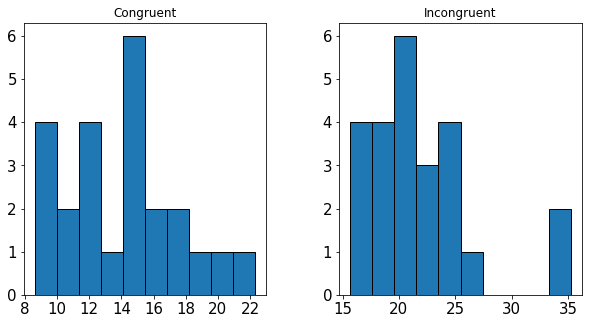

```python
# Build the visualizations here
df.hist(grid=False, edgecolor = 'Black', figsize = (10,5), ylabelsize=15, xlabelsize=15)
```

From the graphs, we can see that the peak of the distribution of the time data for the congruent tasks is between 14 and 16, and that the shape of the distribution is relatively more normal than that of the time data for the Incongruent tasks.

When we look at the graph of the time data for the incongruent tasks, we can see that it is right skewed, as there is a longer tail on the right side of the graph.

We can also see that there was nobody who took longer than about 27 seconds but less than about 34 seconds to compelete the incongruent task, although there were two people who took longer than 34 seconds to complete the task.

In addition to this, based on the min and max on the x-axis of the graphs, we see that the Incongruent Tasks (Min: 15, Max: 35) generally took more time to complete than the Congruent ones (Min: 8, Max: 22).

(5) Now, perform the statistical test and report the results. What is the confidence level and your critical statistic value? Do you reject the null hypothesis or fail to reject it? Come to a conclusion in terms of the experiment task. Did the results match up with your expectations?

```python
# Perform the statistical test here
stats.ttest_rel(df['Incongruent'], df['Congruent'])
```

```
Ttest_relResult(statistic=8.020706944109957, pvalue=4.1030005857111781e-08)
```